# geminiEDA-usage

```r
library(ggplot2)
library(dplyr)
library(gtsummary)
library(geminiEDA)
library(ggthemes)
library(scales)   # Add this line
```

geminiEDA-usage.R

# Introduction

The `geminiEDA` package provides tools for generating exploratory data analysis (EDA) reports in R. This vignette demonstrates how to use the package to apply custom themes, create plots, and generate summary tables.

## Custom GEMINI Theme

The `geminiEDA` package includes a custom theme for `ggplot2` plots. You can apply this theme to your plots using the `theme_GEMINI` function.

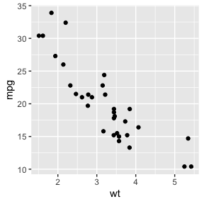

```r
library(ggplot2)
library(geminiEDA)

# Create a sample plot with the default theme
p <- ggplot(mtcars, aes(x = wt, y = mpg)) +
  geom_point()
p
```

geminiEDA-usage.R

Apply the GEMINI theme

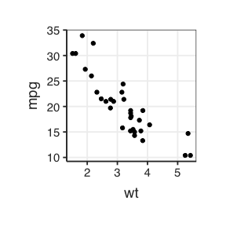

```r
p + theme_GEMINI()
```

geminiEDA-usage.R

## Custom Color and Fill Scales

The package also provides custom color and fill scales for `ggplot2` plots.

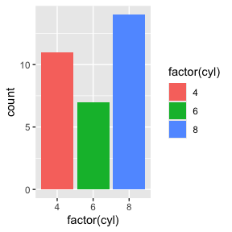

```r
# Create a sample plot with default scales
p <- ggplot(mtcars, aes(x = factor(cyl), fill = factor(cyl))) +
  geom_bar()
p
```

geminiEDA-usage.R

Apply the GEMINI fill scale

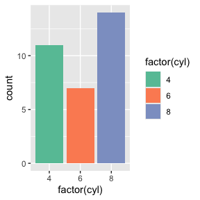

```r
p + scale_fill_GEMINI()
```

geminiEDA-usage.R

Apply the GEMINI theme + fill scale

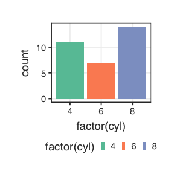

```r
p +
  scale_fill_GEMINI() +
  theme_GEMINI()
```

geminiEDA-usage.R ## Univariate Plot Function

The `eda_univ_autoplot` function creates univariate plots based on the variable type.

### Numeric variable

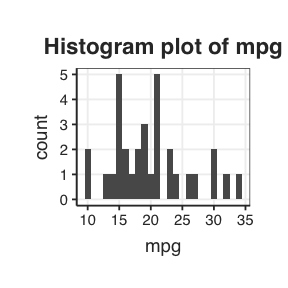

```r
eda_univ_autoplot(mtcars, "mpg")
```

geminiEDA-usage.R ### Categoric variable

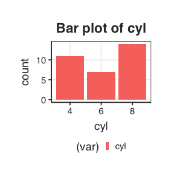

```r
mtcars$cyl <- factor(mtcars$cyl)
eda_univ_autoplot(mtcars, "cyl")
```

geminiEDA-usage.R ## Bivariate Plot Function

The `eda_biv_autoplot` function creates bivariate plots based on the types of the covariate and outcome variables. ### Numeric x Numeric

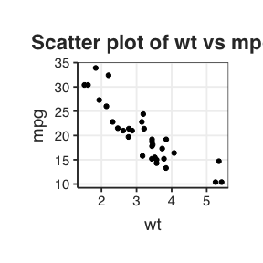

```r
eda_biv_autoplot(mtcars, "wt", "mpg")
```

geminiEDA-usage.R ### Categorical vs. Categorical

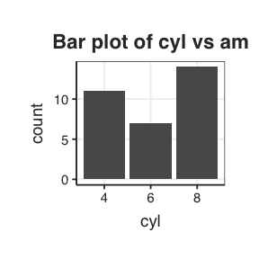

```r
eda_biv_autoplot(mtcars, "cyl", "am")
```

geminiEDA-usage.R ### Categorical vs. Numeric

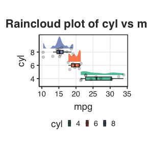

```r
eda_biv_autoplot(mtcars, "cyl", "mpg")
```

geminiEDA-usage.R ## Summary Table Functions

The package includes functions to generate summary tables for univariate and bivariate analyses. ### Univariate tabke

```r
eda_univ_summary(mtcars, "mpg")
```

| **Characteristic** | **N = 32** |
| --- | --- |
| mpg |  |
| Mean (SD) | 20.1 (6.0) |
| Median (IQR) | 19.2 (15.4, 22.8) |
| Range | 10.4, 33.9 |

geminiEDA-usage.R

### Bivariate table

```r
eda_biv_summary(mtcars, "cyl", "mpg")
```

| **Characteristic** | **10.4**, N = 2<sup>1</sup> | **13.3**, N = 1<sup>1</sup> | **14.3**, N = 1<sup>1</sup> | **14.7**, N = 1<sup>1</sup> | **15**, N = 1<sup>1</sup> | **15.2**, N = 2<sup>1</sup> | **15.5**, N = 1<sup>1</sup> | **15.8**, N = 1<sup>1</sup> | **16.4**, N = 1<sup>1</sup> | **17.3**, N = 1<sup>1</sup> | **17.8**, N = 1<sup>1</sup> | **18.1**, N = 1<sup>1</sup> | **18.7**, N = 1<sup>1</sup> | **19.2**, N = 2<sup>1</sup> | **19.7**, N = 1<sup>1</sup> | **21**, N = 2<sup>1</sup> | **21.4**, N = 2<sup>1</sup> | **21.5**, N = 1<sup>1</sup> | **22.8**, N = 2<sup>1</sup> | **24.4**, N = 1<sup>1</sup> | **26**, N = 1<sup>1</sup> | **27.3**, N = 1<sup>1</sup> | **30.4**, N = 2<sup>1</sup> | **32.4**, N = 1<sup>1</sup> | **33.9**, N = 1<sup>1</sup> |
| --- | --- | --- | --- | --- | --- | --- | --- | --- | --- | --- | --- | --- | --- | --- | --- | --- | --- | --- | --- | --- | --- | --- | --- | --- | --- |
| cyl |  |  |  |  |  |  |  |  |  |  |  |  |  |  |  |  |  |  |  |  |  |  |  |  |  |
| 4 | 0 / 2 (0%) | 0 / 1 (0%) | 0 / 1 (0%) | 0 / 1 (0%) | 0 / 1 (0%) | 0 / 2 (0%) | 0 / 1 (0%) | 0 / 1 (0%) | 0 / 1 (0%) | 0 / 1 (0%) | 0 / 1 (0%) | 0 / 1 (0%) | 0 / 1 (0%) | 0 / 2 (0%) | 0 / 1 (0%) | 0 / 2 (0%) | 1 / 2 (50%) | 1 / 1 (100%) | 2 / 2 (100%) | 1 / 1 (100%) | 1 / 1 (100%) | 1 / 1 (100%) | 2 / 2 (100%) | 1 / 1 (100%) | 1 / 1 (100%) |
| 6 | 0 / 2 (0%) | 0 / 1 (0%) | 0 / 1 (0%) | 0 / 1 (0%) | 0 / 1 (0%) | 0 / 2 (0%) | 0 / 1 (0%) | 0 / 1 (0%) | 0 / 1 (0%) | 0 / 1 (0%) | 1 / 1 (100%) | 1 / 1 (100%) | 0 / 1 (0%) | 1 / 2 (50%) | 1 / 1 (100%) | 2 / 2 (100%) | 1 / 2 (50%) | 0 / 1 (0%) | 0 / 2 (0%) | 0 / 1 (0%) | 0 / 1 (0%) | 0 / 1 (0%) | 0 / 2 (0%) | 0 / 1 (0%) | 0 / 1 (0%) |
| 8 | 2 / 2 (100%) | 1 / 1 (100%) | 1 / 1 (100%) | 1 / 1 (100%) | 1 / 1 (100%) | 2 / 2 (100%) | 1 / 1 (100%) | 1 / 1 (100%) | 1 / 1 (100%) | 1 / 1 (100%) | 0 / 1 (0%) | 0 / 1 (0%) | 1 / 1 (100%) | 1 / 2 (50%) | 0 / 1 (0%) | 0 / 2 (0%) | 0 / 2 (0%) | 0 / 1 (0%) | 0 / 2 (0%) | 0 / 1 (0%) | 0 / 1 (0%) | 0 / 1 (0%) | 0 / 2 (0%) | 0 / 1 (0%) | 0 / 1 (0%) |

<sup>1</sup> n / N (%)

geminiEDA-usage.R # Conclusion

This vignette provided an overview of the `geminiEDA` package and demonstrated how to use its functions to create plots and generate summary tables for EDA. For more information, please refer to the package documentation.